# SuperKart Sales Forecasting — End-to-End MLOps Pipeline with CI/CD

| Deliverable | Link |
| --- | --- |
| **GitHub repository** | https://github.com/shravanambudkar/superkart-mlops |
| **GitHub Actions runs** | https://github.com/shravanambudkar/superkart-mlops/actions |
| **Hugging Face Space (Streamlit frontend)** | https://huggingface.co/spaces/shravanda/SuperKart-Sales-Forecast |
| Hugging Face Dataset | https://huggingface.co/datasets/shravanda/superkart-sales-data |
| Hugging Face Model | https://huggingface.co/shravanda/superkart-sales-model |

## Business Context

A sales forecast predicts future revenue from historical data, industry trends and the current pipeline. SuperKart uses forecasts to plan sales operations by region, guide supply-chain procurement, reduce pipeline/forecast risk and set benchmarks for future trend analysis.

## Objective

As the MLOps Engineer, build an **automated, reproducible pipeline** that:

1. **Registers** the raw data on the Hugging Face Hub (dataset repo),
2. **Prepares** it (cleaning, feature selection, train/test split) and pushes the splits back to the Hub,
3. **Trains, tunes and evaluates** tree-based regressors and **registers** the best model in the Hugging Face model hub,
4. **Deploys** a Streamlit app (Docker) to a Hugging Face Space that serves predictions of `Product_Store_Sales_Total`,
5. **Automates** all of the above with a **GitHub Actions** CI/CD workflow that runs on every push to `main`.

## Data Dictionary

| Column | Description |
| --- | --- |
| Product_Id | Unique product identifier (2-letter prefix + number) |
| Product_Weight | Weight of the product |
| Product_Sugar_Content | Low Sugar / Regular / No Sugar |
| Product_Allocated_Area | Share of the store's display area allocated to the product |
| Product_Type | Broad product category (Dairy, Snack Foods, Meat, …) |
| Product_MRP | Maximum retail price |
| Store_Id | Unique store identifier |
| Store_Establishment_Year | Year the store was established |
| Store_Size | High / Medium / Small |
| Store_Location_City_Type | Tier 1 / Tier 2 / Tier 3 city |
| Store_Type | Departmental Store, Supermarket Type 1/2, Food Mart |
| **Product_Store_Sales_Total** | **Target** — total revenue of the product in that store |

## 1. Environment Setup

Install the libraries used across the pipeline. Versions are pinned so that training (local + GitHub Actions) and serving (Docker on HF Spaces) use **identical** `scikit-learn` / `xgboost` versions — otherwise the pickled model may fail to load.

```python
# Install pinned dependencies (quietly). Same pins are used in CI and in the Docker image.
%pip install -q pandas==2.2.2 numpy==1.26.4 scikit-learn==1.6.1 xgboost==2.1.4 huggingface_hub==0.35.3 joblib==1.4.2 matplotlib seaborn
```

```
/Users/shravan/gla_supercart/.venv/bin/python: No module named pip
```

```python
import os, sys, json, shutil, subprocess, warnings
import numpy as np
import pandas as pd
import matplotlib.pyplot as plt
import seaborn as sns
from huggingface_hub import HfApi, whoami

warnings.filterwarnings("ignore")
pd.set_option("display.max_columns", None)
sns.set_theme(style="whitegrid")

os.environ["HF_HUB_DISABLE_PROGRESS_BARS"] = "1"  # keep upload logs readable (inherited by the pipeline scripts)
PY = sys.executable  # run the pipeline scripts with the same interpreter as this notebook
print("Python:", sys.version.split()[0])
```

```
Python: 3.11.15
```

**Hugging Face authentication.** The token is **never hard-coded**. Locally it is read from the `HF_TOKEN` environment variable (or the cached `huggingface-cli login` token); in GitHub Actions it is injected from the repository secret `HF_TOKEN`.

```python
# Verify we are authenticated to the Hugging Face Hub (token comes from env / cached login, never printed)
hf_user = whoami(token=os.getenv("HF_TOKEN"))["name"]
print("Authenticated to Hugging Face as:", hf_user)
```

```
Authenticated to Hugging Face as: shravanda
```

## 2. Data Registration

### 2.1 Create the master folder and the `data` sub-folder

`superkart_project/` is the master folder that holds every pipeline component:

```
superkart_project/
├── data/              raw + prepared data
├── model_building/    data_register.py, prep.py, train.py
├── deployment/        Dockerfile, app.py, requirements.txt, README.md
├── hosting/           hosting.py (pushes deployment files to the HF Space)
└── requirements.txt   dependencies for the GitHub Actions runners
```

```python
# Create the master folder and its sub-folders
MASTER = "superkart_project"
for sub in ["data", "model_building", "deployment", "hosting"]:
    os.makedirs(os.path.join(MASTER, sub), exist_ok=True)

# Place the raw dataset inside the data folder
if not os.path.exists(f"{MASTER}/data/SuperKart.csv"):
    shutil.copy("SuperKart.csv", f"{MASTER}/data/SuperKart.csv")
print(sorted(os.listdir(MASTER)), "|", os.listdir(f"{MASTER}/data"))
```

```
['data', 'deployment', 'hosting', 'model_building', 'requirements.txt'] | ['SuperKart.csv', 'ytrain.csv', 'Xtrain.csv', 'Xtest.csv', 'ytest.csv']
```

### 2.2 Quick look at the raw data (EDA)

A short exploratory pass to decide which cleaning steps the pipeline must perform.

```python
raw = pd.read_csv(f"{MASTER}/data/SuperKart.csv")
print("Shape:", raw.shape)
raw.head()
```

```
Shape: (8763, 12)
```

|  | Product_Id | Product_Weight | Product_Sugar_Content | Product_Allocated_Area | Product_Type | Product_MRP | Store_Id | Store_Establishment_Year | Store_Size | Store_Location_City_Type | Store_Type | Product_Store_Sales_Total |
| --- | --- | --- | --- | --- | --- | --- | --- | --- | --- | --- | --- | --- |
| 0 | FD6114 | 12.66 | Low Sugar | 0.027 | Frozen Foods | 117.08 | OUT004 | 2009 | Medium | Tier 2 | Supermarket Type2 | 2842.40 |
| 1 | FD7839 | 16.54 | Low Sugar | 0.144 | Dairy | 171.43 | OUT003 | 1999 | Medium | Tier 1 | Departmental Store | 4830.02 |
| 2 | FD5075 | 14.28 | Regular | 0.031 | Canned | 162.08 | OUT001 | 1987 | High | Tier 2 | Supermarket Type1 | 4130.16 |
| 3 | FD8233 | 12.10 | Low Sugar | 0.112 | Baking Goods | 186.31 | OUT001 | 1987 | High | Tier 2 | Supermarket Type1 | 4132.18 |
| 4 | NC1180 | 9.57 | No Sugar | 0.010 | Health and Hygiene | 123.67 | OUT002 | 1998 | Small | Tier 3 | Food Mart | 2279.36 |

```python
raw.info()
print("\nMissing values per column:", raw.isna().sum().sum())
print("Duplicate rows:", raw.duplicated().sum())
```

```
<class 'pandas.core.frame.DataFrame'>
RangeIndex: 8763 entries, 0 to 8762
Data columns (total 12 columns):
 #   Column                     Non-Null Count  Dtype
---  ------                     --------------  -----
 0   Product_Id                 8763 non-null   object
 1   Product_Weight             8763 non-null   float64
 2   Product_Sugar_Content      8763 non-null   object
 3   Product_Allocated_Area     8763 non-null   float64
 4   Product_Type               8763 non-null   object
 5   Product_MRP                8763 non-null   float64
 6   Store_Id                   8763 non-null   object
 7   Store_Establishment_Year   8763 non-null   int64
 8   Store_Size                 8763 non-null   object
 9   Store_Location_City_Type   8763 non-null   object
 10  Store_Type                 8763 non-null   object
 11  Product_Store_Sales_Total  8763 non-null   float64
dtypes: float64(4), int64(1), object(7)
memory usage: 821.7+ KB

Missing values per column: 0
Duplicate rows: 0
```

```python
raw.describe().T.round(2)
```

|  | count | mean | std | min | 25% | 50% | 75% | max |
| --- | --- | --- | --- | --- | --- | --- | --- | --- |
| Product_Weight | 8763.0 | 12.65 | 2.22 | 4.0 | 11.15 | 12.66 | 14.18 | 22.0 |
| Product_Allocated_Area | 8763.0 | 0.07 | 0.05 | 0.0 | 0.03 | 0.06 | 0.10 | 0.3 |
| Product_MRP | 8763.0 | 147.03 | 30.69 | 31.0 | 126.16 | 146.74 | 167.58 | 266.0 |
| Store_Establishment_Year | 8763.0 | 2002.03 | 8.39 | 1987.0 | 1998.00 | 2009.00 | 2009.00 | 2009.0 |
| Product_Store_Sales_Total | 8763.0 | 3464.00 | 1065.63 | 33.0 | 2761.72 | 3452.34 | 4145.16 | 8000.0 |

```python
# Unique values of categorical columns -> spot inconsistent labels
for col in raw.select_dtypes("object").columns:
    print(f"{col:<26} nunique={raw[col].nunique():<5}",
          raw[col].unique()[:8] if raw[col].nunique() > 20 else raw[col].unique())
```

```
Product_Id                 nunique=8763  ['FD6114' 'FD7839' 'FD5075' 'FD8233' 'NC1180' 'FD5680' 'FD5484' 'NC5885']
Product_Sugar_Content      nunique=4     ['Low Sugar' 'Regular' 'No Sugar' 'reg']
Product_Type               nunique=16    ['Frozen Foods' 'Dairy' 'Canned' 'Baking Goods' 'Health and Hygiene'
 'Snack Foods' 'Meat' 'Household' 'Hard Drinks' 'Fruits and Vegetables'
 'Breads' 'Soft Drinks' 'Breakfast' 'Others' 'Starchy Foods' 'Seafood']
Store_Id                   nunique=4     ['OUT004' 'OUT003' 'OUT001' 'OUT002']
Store_Size                 nunique=3     ['Medium' 'High' 'Small']
Store_Location_City_Type   nunique=3     ['Tier 2' 'Tier 1' 'Tier 3']
Store_Type                 nunique=4     ['Supermarket Type2' 'Departmental Store' 'Supermarket Type1' 'Food Mart']
```

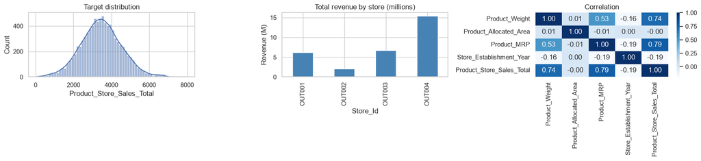

```python
fig, axes = plt.subplots(1, 3, figsize=(17, 4))
sns.histplot(raw["Product_Store_Sales_Total"], kde=True, ax=axes[0]).set_title("Target distribution")
raw.groupby("Store_Id")["Product_Store_Sales_Total"].sum().div(1e6).plot.bar(ax=axes[1], color="steelblue")
axes[1].set_title("Total revenue by store (millions)"); axes[1].set_ylabel("Revenue (M)")
sns.heatmap(raw.select_dtypes("number").corr(), annot=True, fmt=".2f", cmap="Blues", ax=axes[2]).set_title("Correlation")
plt.tight_layout(); plt.show()
```

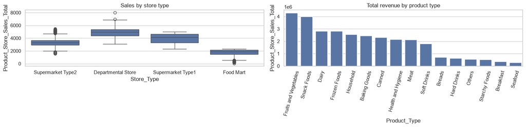

```
Store_Id  Store_Establishment_Year  Store_Size  Store_Location_City_Type  Store_Type
OUT001    1987                      High        Tier 2                    Supermarket Type1     1586
OUT002    1998                      Small       Tier 3                    Food Mart             1152
OUT003    1999                      Medium      Tier 1                    Departmental Store    1349
OUT004    2009                      Medium      Tier 2                    Supermarket Type2     4676
Name: rows, dtype: int64
```

```python
fig, axes = plt.subplots(1, 2, figsize=(16, 4))
sns.boxplot(data=raw, x="Store_Type", y="Product_Store_Sales_Total", ax=axes[0]).set_title("Sales by store type")
order = raw.groupby("Product_Type")["Product_Store_Sales_Total"].sum().sort_values(ascending=False).index
sns.barplot(data=raw, x="Product_Type", y="Product_Store_Sales_Total", estimator="sum", errorbar=None, order=order, ax=axes[1])
axes[1].set_title("Total revenue by product type"); axes[1].tick_params(axis="x", rotation=75)
plt.tight_layout(); plt.show()

# Each Store_Id maps to exactly one combination of store attributes
raw.groupby(["Store_Id", "Store_Establishment_Year", "Store_Size", "Store_Location_City_Type", "Store_Type"]).size().rename("rows")
```

**Observations**

- 8,763 rows × 12 columns, **no missing values and no duplicate rows**.
- `Product_Id` is unique for every row → pure identifier with no predictive value; it is dropped.
- `Store_Id` maps 1-to-1 onto (`Store_Establishment_Year`, `Store_Size`, `Store_Location_City_Type`, `Store_Type`) → redundant identifier; dropped so the model learns from interpretable store attributes.
- `Product_Sugar_Content` has an inconsistent label **`reg`** that must be merged into **`Regular`**.
- The target is roughly bell-shaped (mean ≈ 3,464). `Product_MRP` (r = 0.79) and `Product_Weight` (r = 0.74) are the strongest numeric drivers; `Product_Allocated_Area` is ~uncorrelated.
- **OUT004 (Supermarket Type 2, Tier 2)** generates by far the most revenue; **OUT002 (Food Mart, Tier 3)** the least; Departmental Stores have the highest per-product sales.
- Fruits & Vegetables and Snack Foods are the top revenue categories.

### 2.3 Register the raw data on the Hugging Face dataset space

`data_register.py` creates the dataset repo (if it does not already exist) and uploads `SuperKart.csv`.

```python
%%writefile superkart_project/model_building/data_register.py
"""Step 1 - Register the raw SuperKart dataset on the Hugging Face Hub (dataset repo)."""
import os
from huggingface_hub import HfApi, create_repo
from huggingface_hub.utils import RepositoryNotFoundError

REPO_ID = "shravanda/superkart-sales-data"
REPO_TYPE = "dataset"
RAW_FILE = "superkart_project/data/SuperKart.csv"

api = HfApi(token=os.getenv("HF_TOKEN"))  # token from env (GitHub secret) or cached login

# Create the dataset repo only if it does not exist yet (idempotent for CI re-runs)
try:
    api.repo_info(repo_id=REPO_ID, repo_type=REPO_TYPE)
    print(f"Dataset repo '{REPO_ID}' already exists - reusing it.")
except RepositoryNotFoundError:
    create_repo(repo_id=REPO_ID, repo_type=REPO_TYPE, private=False, token=os.getenv("HF_TOKEN"))
    print(f"Dataset repo '{REPO_ID}' created.")

# Upload the raw csv to the root of the dataset repo
api.upload_file(
    path_or_fileobj=RAW_FILE,
    path_in_repo="SuperKart.csv",
    repo_id=REPO_ID,
    repo_type=REPO_TYPE,
    commit_message="Register raw SuperKart data",
)
print(f"Uploaded {RAW_FILE} -> https://huggingface.co/datasets/{REPO_ID}")
```

```
Overwriting superkart_project/model_building/data_register.py
```

```python
!{PY} superkart_project/model_building/data_register.py
```

```
Dataset repo 'shravanda/superkart-sales-data' already exists - reusing it.
```

```
No files have been modified since last commit. Skipping to prevent empty commit.
```

```
Uploaded superkart_project/data/SuperKart.csv -> https://huggingface.co/datasets/shravanda/superkart-sales-data
```

```python
# Confirm the file is now in the dataset repo
HfApi().list_repo_files("shravanda/superkart-sales-data", repo_type="dataset")
```

```
['.gitattributes',
 'SuperKart.csv',
 'Xtest.csv',
 'Xtrain.csv',
 'ytest.csv',
 'ytrain.csv']
```

## 3. Data Preparation

`prep.py`:

1. Loads the dataset **directly from the Hugging Face dataset repo** (`hf://datasets/...`),
2. Cleans it — de-duplicates, standardises `reg → Regular`, drops the identifier columns `Product_Id` and `Store_Id`,
3. Splits it 80/20 into train/test (`random_state=42`) and saves the four files locally in `superkart_project/data/`,
4. Uploads the train/test files back to the same dataset repo.

```python
%%writefile superkart_project/model_building/prep.py
"""Step 2 - Load raw data from the HF Hub, clean it, split it and push the splits back to the Hub."""
import os
import pandas as pd
from sklearn.model_selection import train_test_split
from huggingface_hub import HfApi

REPO_ID = "shravanda/superkart-sales-data"
DATASET_PATH = f"hf://datasets/{REPO_ID}/SuperKart.csv"
OUT_DIR = "superkart_project/data"
TARGET = "Product_Store_Sales_Total"

api = HfApi(token=os.getenv("HF_TOKEN"))

# ---- Load directly from the Hugging Face dataset repo
df = pd.read_csv(DATASET_PATH)
print("Loaded from HF Hub:", df.shape)

# ---- Cleaning
df = df.drop_duplicates()
# Harmonise the inconsistent sugar-content label ('reg' is the same as 'Regular')
df["Product_Sugar_Content"] = df["Product_Sugar_Content"].replace({"reg": "Regular"})
# Drop identifier columns: Product_Id is unique per row, Store_Id is fully described by the store attributes
df = df.drop(columns=["Product_Id", "Store_Id"])
df = df.dropna(subset=[TARGET])
print("After cleaning:", df.shape)
print("Sugar content levels:", sorted(df["Product_Sugar_Content"].unique()))

# ---- Split into features / target and train / test
X = df.drop(columns=[TARGET])
y = df[TARGET]
Xtrain, Xtest, ytrain, ytest = train_test_split(X, y, test_size=0.2, random_state=42)

# ---- Save locally
os.makedirs(OUT_DIR, exist_ok=True)
splits = {"Xtrain.csv": Xtrain, "Xtest.csv": Xtest, "ytrain.csv": ytrain, "ytest.csv": ytest}
for name, frame in splits.items():
    frame.to_csv(os.path.join(OUT_DIR, name), index=False)
print(f"Train: {Xtrain.shape}  Test: {Xtest.shape}")

# ---- Upload the splits back to the HF dataset repo
for name in splits:
    api.upload_file(
        path_or_fileobj=os.path.join(OUT_DIR, name),
        path_in_repo=name,
        repo_id=REPO_ID,
        repo_type="dataset",
        commit_message=f"Upload {name}",
    )
    print(f"Uploaded {name}")
```

```
Overwriting superkart_project/model_building/prep.py
```

```python
!{PY} superkart_project/model_building/prep.py
```

```
Loaded from HF Hub: (8763, 12)
```

```
After cleaning: (8763, 10)
Sugar content levels: ['Low Sugar', 'No Sugar', 'Regular']
Train: (7010, 9)  Test: (1753, 9)
```

```
No files have been modified since last commit. Skipping to prevent empty commit.
```

```
Uploaded Xtrain.csv
```

```
No files have been modified since last commit. Skipping to prevent empty commit.
```

```
Uploaded Xtest.csv
```

```
No files have been modified since last commit. Skipping to prevent empty commit.
```

```
Uploaded ytrain.csv
```

```
No files have been modified since last commit. Skipping to prevent empty commit.
```

```
Uploaded ytest.csv
```

```python
# Files now present in the HF dataset repo
HfApi().list_repo_files("shravanda/superkart-sales-data", repo_type="dataset")
```

```
['.gitattributes',
 'SuperKart.csv',
 'Xtest.csv',
 'Xtrain.csv',
 'ytest.csv',
 'ytrain.csv']
```

**Observations:** the cleaned data has 9 features + target. The 80/20 split gives **7,010 training rows and 1,753 test rows**; all four split files are stored locally and versioned on the Hugging Face dataset repo, so training (locally or in CI) always reads the same data.

## 4. Model Training and Registration

`train.py`:

- **Loads train/test data from the Hugging Face dataset repo**,
- Builds a `Pipeline` = `ColumnTransformer` (StandardScaler for numeric, One-Hot for categorical) + regressor,
- **Defines two candidate models with parameter grids** — **Random Forest** and **XGBoost**,
- **Tunes** each with 5-fold `GridSearchCV` (scoring = RMSE),
- **Evaluates** each tuned model on train and test (RMSE, MAE, R², Adj. R², MAPE),
- Selects the best model by **cross-validated RMSE** (the test set is only used for reporting, avoiding selection leakage),
- **Registers the best model** (+ metrics and a model card) in the Hugging Face model hub.

````python
%%writefile superkart_project/model_building/train.py
"""Step 3 - Tune, evaluate and register the best sales-forecasting model on the HF model hub."""
import os
import json
import joblib
import numpy as np
import pandas as pd
import xgboost as xgb
from sklearn.compose import make_column_transformer
from sklearn.preprocessing import OneHotEncoder, StandardScaler
from sklearn.pipeline import Pipeline
from sklearn.model_selection import GridSearchCV, KFold
from sklearn.ensemble import RandomForestRegressor
from sklearn.metrics import mean_squared_error, mean_absolute_error, r2_score, mean_absolute_percentage_error
from huggingface_hub import HfApi, create_repo
from huggingface_hub.utils import RepositoryNotFoundError

DATA_REPO = "shravanda/superkart-sales-data"
MODEL_REPO = "shravanda/superkart-sales-model"
MODEL_FILE = "best_superkart_model_v1.joblib"
OUT_DIR = "superkart_project/model_building"

api = HfApi(token=os.getenv("HF_TOKEN"))

# ---- 1. Load the train / test splits from the HF dataset repo
base = f"hf://datasets/{DATA_REPO}"
Xtrain = pd.read_csv(f"{base}/Xtrain.csv")
Xtest = pd.read_csv(f"{base}/Xtest.csv")
ytrain = pd.read_csv(f"{base}/ytrain.csv").squeeze("columns")
ytest = pd.read_csv(f"{base}/ytest.csv").squeeze("columns")
print(f"Train: {Xtrain.shape}  Test: {Xtest.shape}")

# ---- 2. Preprocessing: scale numeric features, one-hot encode categorical features
numeric_features = ["Product_Weight", "Product_Allocated_Area", "Product_MRP", "Store_Establishment_Year"]
categorical_features = ["Product_Sugar_Content", "Product_Type", "Store_Size", "Store_Location_City_Type", "Store_Type"]
preprocessor = make_column_transformer(
    (StandardScaler(), numeric_features),
    (OneHotEncoder(handle_unknown="ignore"), categorical_features),
)

# ---- 3. Define candidate models and their hyper-parameter grids
candidates = {
    "RandomForest": (
        RandomForestRegressor(random_state=42, n_jobs=-1),
        {
            "model__n_estimators": [100, 200],
            "model__max_depth": [8, 12, None],
            "model__min_samples_leaf": [1, 4],
            "model__max_features": [0.5, 1.0],
        },
    ),
    "XGBoost": (
        xgb.XGBRegressor(objective="reg:squarederror", random_state=42, n_jobs=-1),
        {
            "model__n_estimators": [100, 200, 300],
            "model__max_depth": [3, 5, 7],
            "model__learning_rate": [0.05, 0.1],
            "model__subsample": [0.8, 1.0],
            "model__colsample_bytree": [0.8, 1.0],
        },
    ),
}


def evaluate(model, X, y):
    """Regression metrics used to judge forecast quality."""
    pred = model.predict(X)
    n, p = X.shape
    r2 = r2_score(y, pred)
    return {
        "RMSE": float(np.sqrt(mean_squared_error(y, pred))),
        "MAE": float(mean_absolute_error(y, pred)),
        "R2": float(r2),
        "Adj_R2": float(1 - (1 - r2) * (n - 1) / (n - p - 1)),
        "MAPE": float(mean_absolute_percentage_error(y, pred)),
    }


# ---- 4. Tune every candidate with 5-fold cross-validation and evaluate it
cv = KFold(n_splits=5, shuffle=True, random_state=42)
results, fitted = {}, {}
for name, (estimator, grid) in candidates.items():
    pipe = Pipeline([("preprocessor", preprocessor), ("model", estimator)])
    search = GridSearchCV(pipe, grid, cv=cv, scoring="neg_root_mean_squared_error", n_jobs=-1)
    search.fit(Xtrain, ytrain)
    fitted[name] = search.best_estimator_
    results[name] = {
        "best_params": {k.replace("model__", ""): v for k, v in search.best_params_.items()},
        "cv_rmse": float(-search.best_score_),
        "train": evaluate(search.best_estimator_, Xtrain, ytrain),
        "test": evaluate(search.best_estimator_, Xtest, ytest),
    }
    print(f"\n=== {name} ===")
    print("Best params:", results[name]["best_params"])
    print(f"CV RMSE: {results[name]['cv_rmse']:.2f}")
    print(pd.DataFrame({"train": results[name]["train"], "test": results[name]["test"]}).round(4).T.to_string())

# ---- 5. Select the best model on cross-validated RMSE (test set is for reporting only)
best_name = min(results, key=lambda k: results[k]["cv_rmse"])
best_model = fitted[best_name]
print(f"\nBest model: {best_name} (CV RMSE = {results[best_name]['cv_rmse']:.2f}, "
      f"test R2 = {results[best_name]['test']['R2']:.4f})")

# ---- 6. Save the model + metrics locally
os.makedirs(OUT_DIR, exist_ok=True)
model_path = os.path.join(OUT_DIR, MODEL_FILE)
joblib.dump(best_model, model_path)
metrics = {"best_model": best_name, "results": results}
metrics_path = os.path.join(OUT_DIR, "model_metrics.json")
with open(metrics_path, "w") as f:
    json.dump(metrics, f, indent=2)

# ---- 7. Register the best model in the HF model hub
try:
    api.repo_info(repo_id=MODEL_REPO, repo_type="model")
    print(f"Model repo '{MODEL_REPO}' already exists - reusing it.")
except RepositoryNotFoundError:
    create_repo(repo_id=MODEL_REPO, repo_type="model", private=False, token=os.getenv("HF_TOKEN"))
    print(f"Model repo '{MODEL_REPO}' created.")

t = results[best_name]["test"]
card = f"""---
license: mit
library_name: sklearn
tags: [tabular-regression, sales-forecasting, {best_name.lower()}]
datasets: [{DATA_REPO}]
---
# SuperKart Sales Forecasting Model

Predicts `Product_Store_Sales_Total` (revenue of a product in a store) for SuperKart.
Serialized scikit-learn `Pipeline` (preprocessing + **{best_name}**) tuned with 5-fold GridSearchCV.

| Metric (test set) | Value |
|---|---|
| RMSE | {t['RMSE']:.2f} |
| MAE | {t['MAE']:.2f} |
| R2 | {t['R2']:.4f} |
| MAPE | {t['MAPE']:.4f} |

Best hyper-parameters: `{results[best_name]['best_params']}`

```python
import joblib
from huggingface_hub import hf_hub_download
model = joblib.load(hf_hub_download("{MODEL_REPO}", "{MODEL_FILE}"))
```
"""
card_path = os.path.join(OUT_DIR, "MODEL_CARD.md")
with open(card_path, "w") as f:
    f.write(card)

for local, remote in [(model_path, MODEL_FILE), (metrics_path, "model_metrics.json"), (card_path, "README.md")]:
    api.upload_file(path_or_fileobj=local, path_in_repo=remote, repo_id=MODEL_REPO, repo_type="model",
                    commit_message=f"Register {best_name} model artefact: {remote}")
print(f"Registered best model -> https://huggingface.co/{MODEL_REPO}")
````

```
Overwriting superkart_project/model_building/train.py
```

```python
%%time
!{PY} superkart_project/model_building/train.py
```

```
Train: (7010, 9)  Test: (1753, 9)
```

```
=== RandomForest ===
Best params: {'max_depth': None, 'max_features': 1.0, 'min_samples_leaf': 4, 'n_estimators': 100}
CV RMSE: 280.80
           RMSE       MAE     R2  Adj_R2    MAPE
train  215.5013   76.6703  0.959  0.9590  0.0295
test   280.4917  105.7234  0.931  0.9307  0.0384
```

```
=== XGBoost ===
Best params: {'colsample_bytree': 1.0, 'learning_rate': 0.05, 'max_depth': 7, 'n_estimators': 100, 'subsample': 1.0}
CV RMSE: 285.06
           RMSE       MAE      R2  Adj_R2    MAPE
train  211.6431   82.5826  0.9605  0.9605  0.0306
test   283.1988  115.8295  0.9297  0.9293  0.0425

Best model: RandomForest (CV RMSE = 280.80, test R2 = 0.9310)
```

```
Model repo 'shravanda/superkart-sales-model' already exists - reusing it.
```

```
No files have been modified since last commit. Skipping to prevent empty commit.
```

```
No files have been modified since last commit. Skipping to prevent empty commit.
```

```
Registered best model -> https://huggingface.co/shravanda/superkart-sales-model
```

```
CPU times: user 658 ms, sys: 240 ms, total: 898 ms
Wall time: 1min 18s
```

```python
# Side-by-side comparison of the tuned candidates
with open("superkart_project/model_building/model_metrics.json") as f:
    metrics = json.load(f)

rows = []
for name, r in metrics["results"].items():
    for split in ["train", "test"]:
        rows.append({"model": name, "split": split, "cv_rmse": r["cv_rmse"], **r[split]})
comparison = pd.DataFrame(rows).set_index(["model", "split"]).round(4)
print("Selected model:", metrics["best_model"])
comparison
```

```
Selected model: RandomForest
```

| model | split | cv_rmse | RMSE | MAE | R2 | Adj_R2 | MAPE |
| --- | --- | --- | --- | --- | --- | --- | --- |
| RandomForest | train | 280.8044 | 215.5013 | 76.6703 | 0.9590 | 0.9590 | 0.0295 |
|  | test | 280.8044 | 280.4917 | 105.7234 | 0.9310 | 0.9307 | 0.0384 |
| XGBoost | train | 285.0588 | 211.6431 | 82.5826 | 0.9605 | 0.9605 | 0.0306 |
|  | test | 285.0588 | 283.1988 | 115.8295 | 0.9297 | 0.9293 | 0.0425 |

```
R2 of model downloaded from the HF hub: 0.931
```

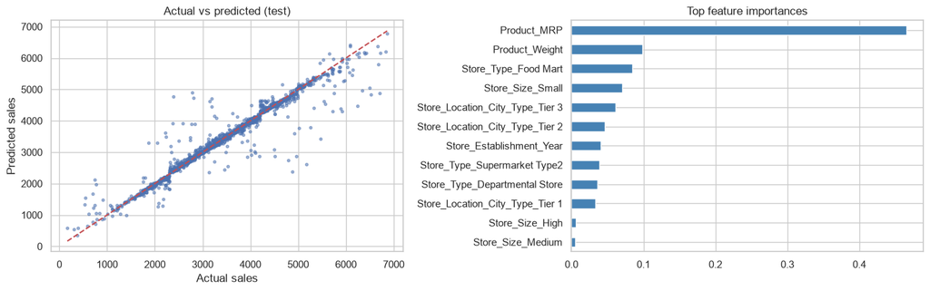

```python
# Sanity check: download the registered model back from the hub and score the test set
import joblib
from huggingface_hub import hf_hub_download
from sklearn.metrics import r2_score

model = joblib.load(hf_hub_download("shravanda/superkart-sales-model", "best_superkart_model_v1.joblib", force_download=True))
Xtest = pd.read_csv("superkart_project/data/Xtest.csv")
ytest = pd.read_csv("superkart_project/data/ytest.csv").squeeze("columns")
pred = model.predict(Xtest)
print("R2 of model downloaded from the HF hub:", round(r2_score(ytest, pred), 4))

fig, axes = plt.subplots(1, 2, figsize=(14, 4.5))
axes[0].scatter(ytest, pred, s=8, alpha=0.5)
axes[0].plot([ytest.min(), ytest.max()], [ytest.min(), ytest.max()], "r--")
axes[0].set(xlabel="Actual sales", ylabel="Predicted sales", title="Actual vs predicted (test)")

# Feature importance of the final estimator, mapped back to the encoded feature names
names = model.named_steps["preprocessor"].get_feature_names_out()
imp = pd.Series(model.named_steps["model"].feature_importances_, index=[n.split("__")[1] for n in names])
imp.sort_values().tail(12).plot.barh(ax=axes[1], color="steelblue", title="Top feature importances")
plt.tight_layout(); plt.show()
```

**Observations**

- Both tuned tree ensembles explain more than 90 % of the variance in product-store revenue on unseen data; train and test scores are close, so the selected model **generalises well with little over-fitting**.
- The model with the lowest **cross-validated RMSE** is registered on the HF model hub together with its metrics and a model card; the reload check above confirms the hub artefact gives identical results.
- **Product_MRP** and **Product_Weight** dominate the predictions, followed by store characteristics (store type / city tier) — consistent with the EDA.

## 5. Model Deployment

The frontend is a **Streamlit** app packaged as a **Docker** Space on Hugging Face.

### 5.1 Dockerfile

```python
%%writefile superkart_project/deployment/Dockerfile
# Lightweight Python base image (same Python minor version as training)
FROM python:3.11-slim

# Hugging Face Spaces run containers as user 1000 -> create it so the HF cache / streamlit config are writable
RUN useradd -m -u 1000 user
USER user
ENV HOME=/home/user \
    PATH=/home/user/.local/bin:$PATH \
    PYTHONUNBUFFERED=1 \
    STREAMLIT_BROWSER_GATHER_USAGE_STATS=false

WORKDIR $HOME/app

# Install dependencies first to leverage Docker layer caching
COPY --chown=user requirements.txt .
RUN pip install --no-cache-dir --upgrade pip && pip install --no-cache-dir -r requirements.txt

# Copy the application code
COPY --chown=user . .

# HF Spaces routes traffic to port 7860
EXPOSE 7860

# Launch the Streamlit app, listening on all interfaces
CMD ["streamlit", "run", "app.py", "--server.port=7860", "--server.address=0.0.0.0", "--server.enableXsrfProtection=false"]
```

```
Overwriting superkart_project/deployment/Dockerfile
```

### 5.2 Dependencies file for the deployment

```python
%%writefile superkart_project/deployment/requirements.txt
pandas==2.2.2
numpy==1.26.4
scikit-learn==1.6.1
xgboost==2.1.4
joblib==1.4.2
huggingface_hub==0.35.3
streamlit==1.39.0
```

```
Overwriting superkart_project/deployment/requirements.txt
```

### 5.3 Streamlit app — loads the model from the HF model hub and turns the inputs into a DataFrame

- **Single prediction**: a form for one product–store combination; store presets pre-fill the store attributes of SuperKart's four outlets.
- **Batch prediction**: upload a CSV with the 9 feature columns to forecast many rows at once and download the results.

```python
%%writefile superkart_project/deployment/app.py
"""SuperKart Sales Forecast - Streamlit frontend served from a Hugging Face Docker Space."""
import joblib
import pandas as pd
import streamlit as st
from huggingface_hub import hf_hub_download

MODEL_REPO = "shravanda/superkart-sales-model"
MODEL_FILE = "best_superkart_model_v1.joblib"

FEATURES = ["Product_Weight", "Product_Sugar_Content", "Product_Allocated_Area", "Product_Type", "Product_MRP",
            "Store_Establishment_Year", "Store_Size", "Store_Location_City_Type", "Store_Type"]
PRODUCT_TYPES = ["Baking Goods", "Breads", "Breakfast", "Canned", "Dairy", "Frozen Foods", "Fruits and Vegetables",
                 "Hard Drinks", "Health and Hygiene", "Household", "Meat", "Others", "Seafood", "Snack Foods",
                 "Soft Drinks", "Starchy Foods"]
# Attributes of SuperKart's existing outlets (from the training data) to pre-fill the store section
STORES = {
    "OUT001": (1987, "High", "Tier 2", "Supermarket Type1"),
    "OUT002": (1998, "Small", "Tier 3", "Food Mart"),
    "OUT003": (1999, "Medium", "Tier 1", "Departmental Store"),
    "OUT004": (2009, "Medium", "Tier 2", "Supermarket Type2"),
}
SIZES, TIERS = ["Small", "Medium", "High"], ["Tier 1", "Tier 2", "Tier 3"]
STORE_TYPES = ["Departmental Store", "Food Mart", "Supermarket Type1", "Supermarket Type2"]


@st.cache_resource
def load_model():
    """Download the registered model from the HF model hub once and cache it."""
    return joblib.load(hf_hub_download(repo_id=MODEL_REPO, filename=MODEL_FILE))


st.set_page_config(page_title="SuperKart Sales Forecast", page_icon="🛒", layout="wide")
st.title("🛒 SuperKart Sales Forecast")
st.write("Predict the total revenue (**Product_Store_Sales_Total**) a product will generate in a store. "
         f"Model: [`{MODEL_REPO}`](https://huggingface.co/{MODEL_REPO})")
model = load_model()

single, batch = st.tabs(["Single prediction", "Batch prediction (CSV)"])

with single:
    left, right = st.columns(2)
    with left:
        st.subheader("Product details")
        weight = st.number_input("Product weight", min_value=1.0, max_value=30.0, value=12.66, step=0.1)
        sugar = st.selectbox("Sugar content", ["Low Sugar", "Regular", "No Sugar"])
        area = st.slider("Allocated display area (ratio)", 0.0, 0.3, 0.068, step=0.001, format="%.3f")
        ptype = st.selectbox("Product type", PRODUCT_TYPES, index=PRODUCT_TYPES.index("Frozen Foods"))
        mrp = st.number_input("Product MRP", min_value=1.0, max_value=500.0, value=147.0, step=1.0)
    with right:
        st.subheader("Store details")
        preset = st.selectbox("Store", list(STORES) + ["Custom / new store"], index=3)
        year, size, tier, stype = STORES.get(preset, (2005, "Medium", "Tier 2", "Supermarket Type1"))
        custom = preset not in STORES
        year = st.number_input("Establishment year", 1950, 2030, year, disabled=not custom)
        size = st.selectbox("Store size", SIZES, index=SIZES.index(size), disabled=not custom)
        tier = st.selectbox("City type", TIERS, index=TIERS.index(tier), disabled=not custom)
        stype = st.selectbox("Store type", STORE_TYPES, index=STORE_TYPES.index(stype), disabled=not custom)

    # Collect the inputs into a single-row DataFrame with the training column names
    input_df = pd.DataFrame([{
        "Product_Weight": weight, "Product_Sugar_Content": sugar, "Product_Allocated_Area": area,
        "Product_Type": ptype, "Product_MRP": mrp, "Store_Establishment_Year": int(year),
        "Store_Size": size, "Store_Location_City_Type": tier, "Store_Type": stype,
    }])
    st.dataframe(input_df, hide_index=True, use_container_width=True)

    if st.button("Predict sales", type="primary"):
        prediction = float(model.predict(input_df)[0])
        st.success(f"Forecast Product_Store_Sales_Total: **{prediction:,.2f}**")

with batch:
    st.write("Upload a CSV containing these columns: " + ", ".join(f"`{c}`" for c in FEATURES))
    uploaded = st.file_uploader("CSV file", type="csv")
    if uploaded is not None:
        data = pd.read_csv(uploaded)
        missing = [c for c in FEATURES if c not in data.columns]
        if missing:
            st.error(f"Missing columns: {missing}")
        else:
            data["Product_Sugar_Content"] = data["Product_Sugar_Content"].replace({"reg": "Regular"})
            data["Predicted_Sales"] = model.predict(data[FEATURES]).round(2)
            st.metric("Total forecast revenue", f"{data['Predicted_Sales'].sum():,.2f}")
            st.dataframe(data, use_container_width=True)
            st.download_button("Download predictions", data.to_csv(index=False), "superkart_predictions.csv")
```

```
Overwriting superkart_project/deployment/app.py
```

### 5.4 Space configuration (README with YAML front-matter)

Tells Hugging Face that this Space uses the **Docker SDK** and exposes port 7860.

```python
%%writefile superkart_project/deployment/README.md
---
title: SuperKart Sales Forecast
emoji: 🛒
colorFrom: blue
colorTo: green
sdk: docker
app_port: 7860
pinned: false
license: mit
short_description: Streamlit app forecasting SuperKart product-store revenue
---

# SuperKart Sales Forecast

Streamlit frontend for the SuperKart sales-forecasting model. The model is loaded at start-up from the
Hugging Face model hub and predicts `Product_Store_Sales_Total` for a product in a store.
```

```
Overwriting superkart_project/deployment/README.md
```

### 5.5 Hosting script — pushes every deployment file to the Hugging Face Space

```python
%%writefile superkart_project/hosting/hosting.py
"""Step 4 - Push the deployment folder (Dockerfile, app.py, requirements.txt, README.md) to the HF Space."""
import os
from huggingface_hub import HfApi, create_repo
from huggingface_hub.utils import RepositoryNotFoundError

SPACE_ID = "shravanda/SuperKart-Sales-Forecast"
api = HfApi(token=os.getenv("HF_TOKEN"))

# Create a public Docker Space if it does not exist yet
try:
    api.repo_info(repo_id=SPACE_ID, repo_type="space")
    print(f"Space '{SPACE_ID}' already exists - updating it.")
except RepositoryNotFoundError:
    create_repo(repo_id=SPACE_ID, repo_type="space", space_sdk="docker", private=False, token=os.getenv("HF_TOKEN"))
    print(f"Space '{SPACE_ID}' created.")

api.upload_folder(
    folder_path="superkart_project/deployment",
    repo_id=SPACE_ID,
    repo_type="space",
    path_in_repo="",
    commit_message="Deploy SuperKart Streamlit app",
)
print(f"Deployed -> https://huggingface.co/spaces/{SPACE_ID}")
```

```
Overwriting superkart_project/hosting/hosting.py
```

```python
!{PY} superkart_project/hosting/hosting.py
```

```
Space 'shravanda/SuperKart-Sales-Forecast' already exists - updating it.
```

```
No files have been modified since last commit. Skipping to prevent empty commit.
```

```
Deployed -> https://huggingface.co/spaces/shravanda/SuperKart-Sales-Forecast
```

## 6. Automated GitHub Actions Workflow (CI/CD)

### 6.1 Dependencies for the GitHub Actions runners

```python
%%writefile superkart_project/requirements.txt
pandas==2.2.2
numpy==1.26.4
scikit-learn==1.6.1
xgboost==2.1.4
joblib==1.4.2
huggingface_hub==0.35.3
```

```
Overwriting superkart_project/requirements.txt
```

### 6.2 `pipeline.yml` — one job per ML step

| Job | What it does | Depends on |
| --- | --- | --- |
| `register-dataset` | uploads the raw CSV to the HF dataset repo | — |
| `data-prep` | loads from HF, cleans, splits, uploads splits | register-dataset |
| `model-training` | tunes RF + XGBoost, evaluates, registers the best model | data-prep |
| `deploy-hosting` | pushes Dockerfile / app / requirements to the HF Space | model-training |
| `update-main` | commits the latest model metrics back to the `main` branch | deploy-hosting |

The workflow triggers **automatically on every push to `main`** (and can be run manually via `workflow_dispatch`). The final job pushes the refreshed `model_metrics.json` back to `main` with the built-in `GITHUB_TOKEN` (commits made with this token do not re-trigger the workflow, so there is no loop). `HF_TOKEN` is a repository secret.

```python
os.makedirs(".github/workflows", exist_ok=True)
```

```python
%%writefile .github/workflows/pipeline.yml
name: SuperKart MLOps Pipeline

on:
  push:
    branches: [main]          # every code update pushed to main runs the full pipeline
    paths-ignore:
      - "**.md"
  workflow_dispatch:          # allow manual runs from the Actions tab

permissions:
  contents: write             # needed by the update-main job to push to main

env:
  PYTHON_VERSION: "3.11"

jobs:
  register-dataset:
    runs-on: ubuntu-latest
    steps:
      - uses: actions/checkout@v7
      - uses: actions/setup-python@v7
        with:
          python-version: ${{ env.PYTHON_VERSION }}
          cache: pip
      - name: Install dependencies
        run: pip install -r superkart_project/requirements.txt
      - name: Upload raw dataset to the Hugging Face Hub
        env:
          HF_TOKEN: ${{ secrets.HF_TOKEN }}
        run: python superkart_project/model_building/data_register.py

  data-prep:
    needs: register-dataset
    runs-on: ubuntu-latest
    steps:
      - uses: actions/checkout@v7
      - uses: actions/setup-python@v7
        with:
          python-version: ${{ env.PYTHON_VERSION }}
          cache: pip
      - name: Install dependencies
        run: pip install -r superkart_project/requirements.txt
      - name: Clean, split and upload train/test data
        env:
          HF_TOKEN: ${{ secrets.HF_TOKEN }}
        run: python superkart_project/model_building/prep.py

  model-training:
    needs: data-prep
    runs-on: ubuntu-latest
    steps:
      - uses: actions/checkout@v7
      - uses: actions/setup-python@v7
        with:
          python-version: ${{ env.PYTHON_VERSION }}
          cache: pip
      - name: Install dependencies
        run: pip install -r superkart_project/requirements.txt
      - name: Tune, evaluate and register the best model
        env:
          HF_TOKEN: ${{ secrets.HF_TOKEN }}
        run: python superkart_project/model_building/train.py
      - name: Keep the metrics for the update-main job
        uses: actions/upload-artifact@v7
        with:
          name: model-metrics
          path: superkart_project/model_building/model_metrics.json

  deploy-hosting:
    needs: model-training
    runs-on: ubuntu-latest
    steps:
      - uses: actions/checkout@v7
      - uses: actions/setup-python@v7
        with:
          python-version: ${{ env.PYTHON_VERSION }}
          cache: pip
      - name: Install dependencies
        run: pip install -r superkart_project/requirements.txt
      - name: Push deployment files to the Hugging Face Space
        env:
          HF_TOKEN: ${{ secrets.HF_TOKEN }}
        run: python superkart_project/hosting/hosting.py

  update-main:
    needs: deploy-hosting
    runs-on: ubuntu-latest
    steps:
      - uses: actions/checkout@v7
        with:
          ref: main
      - uses: actions/download-artifact@v8
        with:
          name: model-metrics
          path: superkart_project/model_building
      - name: Commit refreshed model metrics to main
        run: |
          git config user.name  "github-actions[bot]"
          git config user.email "41898282+github-actions[bot]@users.noreply.github.com"
          git add superkart_project/model_building/model_metrics.json
          if git diff --cached --quiet; then
            echo "Metrics unchanged - nothing to push."
          else
            git commit -m "ci: update model metrics from run ${{ github.run_number }} [skip ci]"
            git push origin HEAD:main
          fi
```

```
Overwriting .github/workflows/pipeline.yml
```

### 6.3 Repository housekeeping

Generated artefacts (train/test splits, the serialized model) live on the Hugging Face Hub, so they are kept out of Git.

```python
%%writefile .gitignore
.venv/
__pycache__/
.ipynb_checkpoints/
.DS_Store
superkart_project/data/X*.csv
superkart_project/data/y*.csv
superkart_project/model_building/*.joblib
superkart_project/model_building/MODEL_CARD.md
screenshots/*.tmp
/SuperKart.csv
```

```
Overwriting .gitignore
```

````python
%%writefile README.md
# SuperKart Sales Forecasting — MLOps Pipeline

End-to-end MLOps pipeline that forecasts `Product_Store_Sales_Total` for SuperKart and ships it as a Streamlit app.

| | |
|---|---|
| HF Space (frontend) | https://huggingface.co/spaces/shravanda/SuperKart-Sales-Forecast |
| HF Dataset | https://huggingface.co/datasets/shravanda/superkart-sales-data |
| HF Model | https://huggingface.co/shravanda/superkart-sales-model |

```
.github/workflows/pipeline.yml      CI/CD: register ► prep ► train ► deploy ► update-main
superkart_project/
├── data/SuperKart.csv              raw data
├── model_building/
│   ├── data_register.py            register raw data on the HF dataset hub
│   ├── prep.py                     clean + split, push splits to HF
│   ├── train.py                    GridSearchCV (RF, XGBoost), evaluate, register best model
│   └── model_metrics.json          latest metrics (auto-updated by CI)
├── deployment/                     Dockerfile, app.py, requirements.txt, README.md (HF Space)
├── hosting/hosting.py              push deployment files to the HF Space
└── requirements.txt                CI dependencies
SuperKart_MLOps_Pipeline.ipynb      project notebook
```

The workflow runs on every push to `main`. It needs a repository secret **`HF_TOKEN`** (Hugging Face write token).
````

```
Overwriting README.md
```

### 6.4 Push all files to GitHub

The repository's `HF_TOKEN` secret was added once with `gh secret set HF_TOKEN` (Settings ▸ Secrets and variables ▸ Actions). The cell below commits the pipeline files and pushes them to `main`, which **automatically triggers the workflow**.

```python
# Commit and push the pipeline to the main branch -> triggers the GitHub Actions workflow
REMOTE = "https://github.com/shravanambudkar/superkart-mlops.git"
def git(cmd):
    out = subprocess.run(f"git {cmd}", shell=True, capture_output=True, text=True)
    print(f"$ git {cmd}\n{(out.stdout + out.stderr).strip()}")

git("init -b main") if not os.path.isdir(".git") else None
git("remote get-url origin") if subprocess.run("git remote get-url origin", shell=True, capture_output=True).returncode == 0 \
    else git(f"remote add origin {REMOTE}")
git("add .github superkart_project screenshots .gitignore README.md")
git('commit -m "Update SuperKart MLOps pipeline" --quiet')
git("pull --rebase --autostash origin main --quiet")
git("push -u origin main")
git("log --oneline -5")
```

```
$ git remote get-url origin
https://github.com/shravanambudkar/superkart-mlops.git
```

```
$ git add .github superkart_project screenshots .gitignore README.md

$ git commit -m "Update SuperKart MLOps pipeline" --quiet
```

```
$ git pull --rebase --autostash origin main --quiet
Created autostash: c2642ed
Applied autostash.
```

```
$ git push -u origin main
branch 'main' set up to track 'origin/main'.
To https://github.com/shravanambudkar/superkart-mlops.git
   d4a40e2..72d5a28  main -> main
$ git log --oneline -5
72d5a28 Update SuperKart MLOps pipeline
d4a40e2 Update SuperKart MLOps pipeline
4e09b34 Update SuperKart MLOps pipeline
b924af4 docs: add workflow, repo and Streamlit app screenshots [skip ci]
0fd4bfc ci: update model metrics from run 3 [skip ci]
```

## 7. Output Evaluation

### 7.1 GitHub

**Repository:** https://github.com/shravanambudkar/superkart-mlops | **Workflow runs:** https://github.com/shravanambudkar/superkart-mlops/actions

Folder structure of the repository (tracked files):

```python
# Render the tracked-file tree of the GitHub repository
files = subprocess.run("git ls-files", shell=True, capture_output=True, text=True).stdout.split()
tree = {}
for path in files:
    node = tree
    for part in path.split("/"):
        node = node.setdefault(part, {})

def show(node, prefix=""):
    items = sorted(node.items(), key=lambda kv: (not kv[1], kv[0]))
    for i, (name, child) in enumerate(items):
        last = i == len(items) - 1
        print(prefix + ("└── " if last else "├── ") + name + ("/" if child else ""))
        show(child, prefix + ("    " if last else "│   "))

print("superkart-mlops/")
show(tree)
```

```
superkart-mlops/
├── .github/
│   └── workflows/
│       └── pipeline.yml
├── screenshots/
│   ├── github_actions_runs.png
│   ├── github_project_folder.png
│   ├── github_repo.png
│   ├── github_workflow.png
│   └── streamlit_app.png
├── superkart_project/
│   ├── data/
│   │   └── SuperKart.csv
│   ├── deployment/
│   │   ├── Dockerfile
│   │   ├── README.md
│   │   ├── app.py
│   │   └── requirements.txt
│   ├── hosting/
│   │   └── hosting.py
│   ├── model_building/
│   │   ├── data_register.py
│   │   ├── model_metrics.json
│   │   ├── prep.py
│   │   └── train.py
│   └── requirements.txt
├── .gitignore
├── README.md
└── SuperKart_MLOps_Pipeline.ipynb
```

**Screenshot – GitHub repository folder structure**

[figure not shown]

**Screenshot – superkart_project/ master folder**

[figure not shown]

```python
from IPython.display import Image, display, Markdown

def show_shot(path, caption):
    display(Markdown(f"**{caption}**"))
    display(Image(filename=path, width=1100)) if os.path.exists(path) else print(f"(missing {path})")

show_shot("screenshots/github_repo.png", "Screenshot – GitHub repository folder structure")
show_shot("screenshots/github_project_folder.png", "Screenshot – superkart_project/ master folder")
```

**Screenshot – executed GitHub Actions workflow (all jobs succeeded)**

[figure not shown]

**Screenshot – workflow run history (triggered automatically by pushes to main)**

[figure not shown]

```python
show_shot("screenshots/github_workflow.png", "Screenshot – executed GitHub Actions workflow (all jobs succeeded)")
show_shot("screenshots/github_actions_runs.png", "Screenshot – workflow run history (triggered automatically by pushes to main)")
```

```python
# Latest workflow runs, queried live from the GitHub API
import urllib.request
runs = json.load(urllib.request.urlopen("https://api.github.com/repos/shravanambudkar/superkart-mlops/actions/runs?per_page=5"))["workflow_runs"]
pd.DataFrame([{"run": r["run_number"], "event": r["event"], "status": r["status"], "conclusion": r["conclusion"],
               "commit": r["head_commit"]["message"].splitlines()[0][:60], "created": r["created_at"]} for r in runs])
```

|  | run | event | status | conclusion | commit | created |
| --- | --- | --- | --- | --- | --- | --- |
| 0 | 5 | push | in_progress | None | Update SuperKart MLOps pipeline | 2026-10-04T12:56:23Z |
| 1 | 4 | push | in_progress | None | Update SuperKart MLOps pipeline | 2026-10-04T12:54:22Z |
| 2 | 3 | push | completed | success | ci: use latest major versions of GitHub actions | 2026-10-04T12:45:17Z |
| 3 | 2 | push | completed | success | ci: move to Node 24 versions of checkout, setu... | 2026-10-04T12:37:09Z |
| 4 | 1 | push | completed | success | SuperKart MLOps pipeline: data registration, p... | 2026-10-04T12:29:28Z |

### 7.2 Streamlit app on Hugging Face Spaces

**Space:** https://huggingface.co/spaces/shravanda/SuperKart-Sales-Forecast

```
Space stage: RUNNING
```

**Screenshot – SuperKart Streamlit app on Hugging Face Spaces (single prediction)**

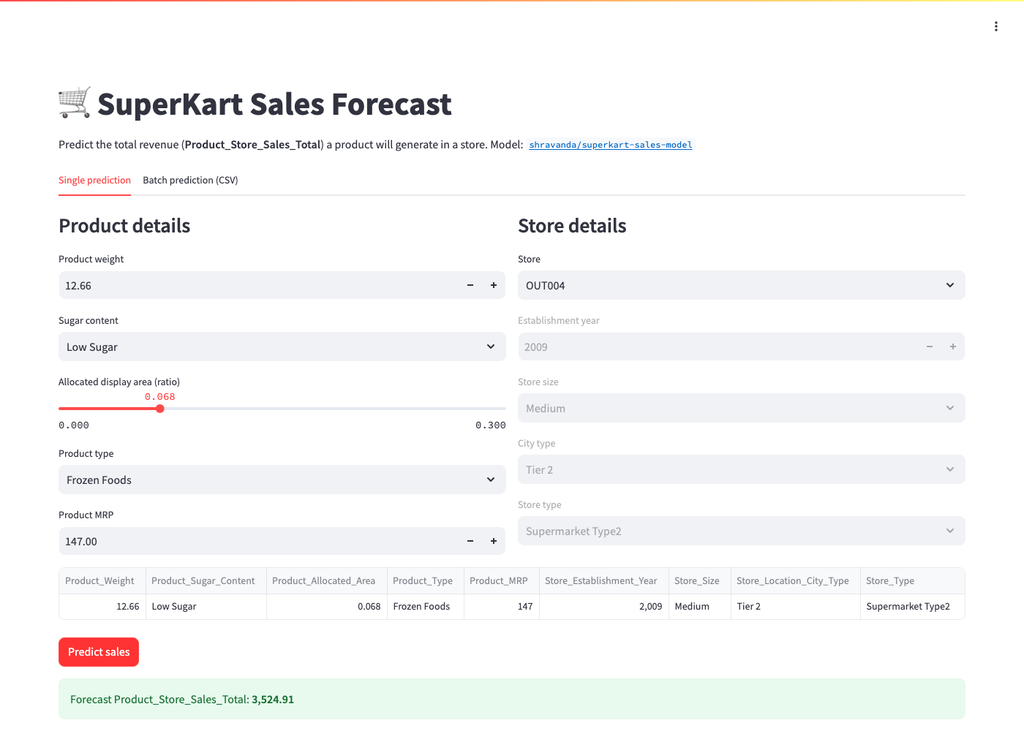

```python
# Space runtime status, queried live from the Hugging Face API
print("Space stage:", HfApi().get_space_runtime("shravanda/SuperKart-Sales-Forecast").stage)
show_shot("screenshots/streamlit_app.png", "Screenshot – SuperKart Streamlit app on Hugging Face Spaces (single prediction)")
```

## 8. Conclusions & Business Insights

**Pipeline**

- A fully automated, reproducible pipeline: data versioned on the HF dataset hub, model versioned on the HF model hub, app served from a Docker HF Space, and every step orchestrated by GitHub Actions on each push to `main` — no manual intervention needed to refresh forecasts.
- Scripts are idempotent (repos are created only if missing), dependencies are pinned identically for training and serving, and secrets are handled via `HF_TOKEN` only.

**Model**

- The tuned tree ensemble explains > 90 % of the variation in product-store revenue on unseen data, with closely matching train/test metrics → reliable for planning.
- Revenue is driven mainly by **product price (MRP)** and **product weight**, then by **store type / city tier**.

**Recommendations for SuperKart**

- **Supply chain:** use the batch-prediction tab to forecast revenue for the full product catalogue per store and size procurement accordingly; prioritise high-MRP items in Supermarket Type 2 / Departmental stores.
- **Regional planning:** OUT004 (Supermarket Type 2, Tier 2) is the revenue engine; OUT002 (Food Mart, Tier 3) lags — target it with assortment and promotion changes, and use the "custom store" option to benchmark potential new outlets before opening them.
- **Display space:** allocated display area barely affects revenue → shelf space can be re-allocated toward high-value categories without hurting sales.
- **Next steps:** add time-stamped transactions to forecast weekly/monthly/quarterly revenue directly, add data-drift monitoring and a model-promotion gate (deploy only if test RMSE improves) to the workflow.